# Interaction between markers

Libraries:

```r
library(xtable)
```

# Calculate interactions

The script *Interaction_calculation_for_review.R* does all the calculation. It cut the genetic map by slices of 5 cM. For each pair of slice, it randomly takes 2 markers and compute a linear model: phenotyp = u + marker1 + marker2 + marker1 x marker2. The R2 and the interaction term p-values are saved. We used it on a calculation cluster.  
We realized it for the 5 traits of the study: NV2012, NV2015, Elisa2012, Elisa2015, qPCR2015.

```
# Not run
cd ~/work/MOSAIQUE_REVIEW_EPISTASIE
for i in $(echo 1A 1B 2A 2B 3A 3B 4A 4B 5A 5B 6A 6B 7A 7B); do qsub -q normal.q -b yes -cwd -N tmp_epistasie "Rscript Interaction_calculation_for_review.R genotypage.csv phenotypage.csv genetic_map.txt $i NV_blup_AR1_2012" ; done
for i in $(echo 1A 1B 2A 2B 3A 3B 4A 4B 5A 5B 6A 6B 7A 7B); do qsub -q normal.q -b yes -cwd -N tmp_epistasie "Rscript Interaction_calculation_for_review.R genotypage.csv phenotypage.csv genetic_map.txt $i ELISA_blup_AR1_2012" ; done
for i in $(echo 1A 1B 2A 2B 3A 3B 4A 4B 5A 5B 6A 6B 7A 7B); do qsub -q normal.q -b yes -cwd -N tmp_epistasie "Rscript Interaction_calculation_for_review.R genotypage.csv phenotypage.csv genetic_map.txt $i NV_blup_AR1_2015" ; done
for i in $(echo 1A 1B 2A 2B 3A 3B 4A 4B 5A 5B 6A 6B 7A 7B); do qsub -q normal.q -b yes -cwd -N tmp_epistasie "Rscript Interaction_calculation_for_review.R genotypage.csv phenotypage.csv genetic_map.txt $i ELISA_blup_AR1_2015" ; done
for i in $(echo 1A 1B 2A 2B 3A 3B 4A 4B 5A 5B 6A 6B 7A 7B); do qsub -q normal.q -b yes -cwd -N tmp_epistasie "Rscript Interaction_calculation_for_review.R genotypage.csv phenotypage.csv genetic_map.txt $i QPCR_blup_AR1_2015" ; done
```

Then, we concatenated the results of each chromosome in a summar file:

```
# Concatenate results (--> ~287000 raws)
cd ~/work/MOSAIQUE_REVIEW_EPISTASIE
more result_epistasie_K_1A_NV_blup_AR1_2012.txt | head -1 > bilan_NV_2012
cat result_epi*NV_blup_AR1_2012* | grep -v "pheno" | cut -f2- -d" " >>  bilan_NV_2012
more result_epistasie_K_1A_ELISA_blup_AR1_2012.txt | head -1 > bilan_Elisa_2012
cat result_epi*ELISA_blup_AR1_2012* | grep -v "pheno" | cut -f2- -d" "  >>  bilan_Elisa_2012
more result_epistasie_K_1A_NV_blup_AR1_2015.txt | head -1 > bilan_NV_2015
cat result_epi*NV_blup_AR1_2015* | grep -v "pheno" | cut -f2- -d" "  >>  bilan_NV_2015
more result_epistasie_K_1A_ELISA_blup_AR1_2015.txt | head -1 > bilan_Elisa_2015
cat result_epi*ELISA_blup_AR1_2015* | grep -v "pheno" | cut -f2- -d" "  >>  bilan_Elisa_2015
more result_epistasie_K_1A_QPCR_blup_AR1_2015.txt | head -1 > bilan_qPCR_2015
cat result_epi*QPCR_blup_AR1_2015* | grep -v "pheno" | cut -f2- -d" "  >>  bilan_qPCR_2015

#Transfert
gzip bilan*
scp holtz@CC2-login.cirad.fr://homedir/holtz/work/MOSAIQUE_REVIEW_EPISTASIE/bila* .
```

# Analysing the interaction

Load files:

```r
# Analyse des fichiers dans R:
NV2012=read.table("bilan_NV_2012.gz", header=T) ; NV2012=NV2012[!is.na(NV2012$pval_inter) , ]
Elisa2012=read.table("bilan_Elisa_2012.gz", header=T) ; Elisa2012=Elisa2012[!is.na(Elisa2012$pval_inter) , ]
NV2015=read.table("bilan_NV_2015.gz", header=T) ; NV2015=NV2015[!is.na(NV2015$pval_inter) , ]
Elisa2015=read.table("bilan_Elisa_2015.gz", header=T) ; Elisa2015=Elisa2015[!is.na(Elisa2015$pval_inter) , ]
qPCR2015=read.table("bilan_qPCR_2015.gz", header=T) ; qPCR2015=qPCR2015[!is.na(qPCR2015$pval_inter) , ]
```

How many comparison did we do?

```r
nrow(NV2012)
```

```
## [1] 174060
```

Histogram of p-values of interaction for each variable:

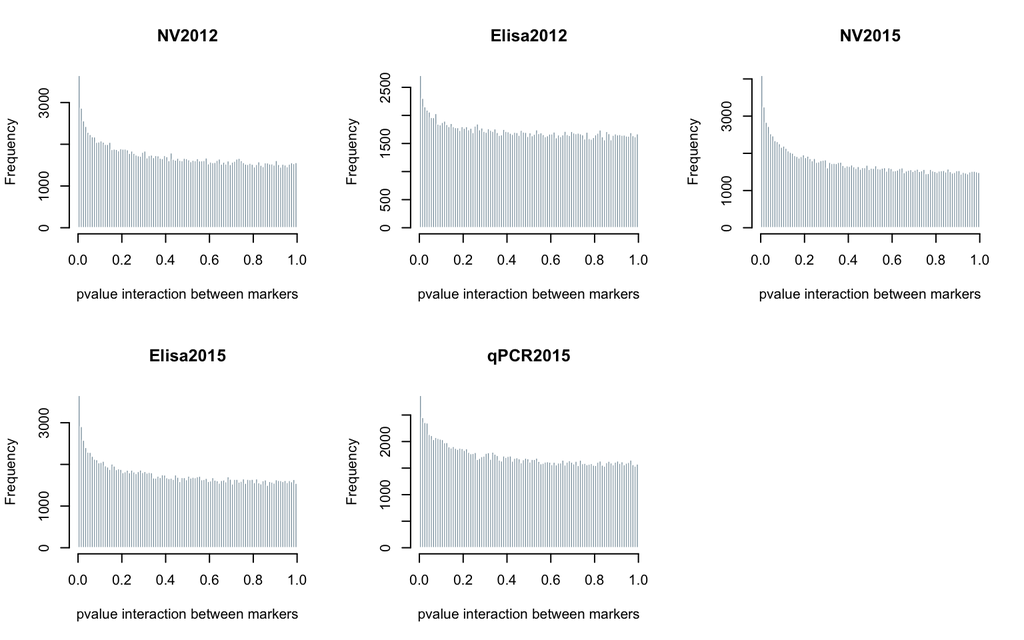

```r
par(mfrow=c(2,3))
hist(NV2012$pval_inter , col=rgb(0.1,0.3,0.4,0.6) , border=F, xlab="pvalue interaction between markers", breaks=100, main="NV2012")
hist(Elisa2012$pval_inter , col=rgb(0.1,0.3,0.4,0.6) , border=F, xlab="pvalue interaction between markers", breaks=100, main="Elisa2012")
hist(NV2015$pval_inter , col=rgb(0.1,0.3,0.4,0.6) , border=F, xlab="pvalue interaction between markers", breaks=100, main="NV2015")
hist(Elisa2015$pval_inter , col=rgb(0.1,0.3,0.4,0.6) , border=F, xlab="pvalue interaction between markers", breaks=100, main="Elisa2015")
hist(qPCR2015$pval_inter , col=rgb(0.1,0.3,0.4,0.6) , border=F, xlab="pvalue interaction between markers", breaks=100, main="qPCR2015")
```

Since the number of test we do si very huge, we will use a false discovery rate (FDR) of 5% as a threshold of significativity. For that we use the qvalue library.

```r
# qvalue library for FDR
library(qvalue)
```

## NV 2012

Calculate qvalue from pvalues

```r
qv = qvalue(p=NV2012$pval_inter, fdr.level=0.05, robust=TRUE)
NV2012$qvalues=qv$qvalues
```

transforme pvalues of markers in LOD:

```r
NV2012$pval_mark1=-log10(NV2012$pval_mark1+0.0000000000000000001)
NV2012$pval_mark2=-log10(NV2012$pval_mark2+0.0000000000000000001)
```

How many significant interactions do we have?

```r
a=NV2012[which(NV2012$qvalues<0.05) , ]
nrow(a)
```

```
## [1] 1
```

|  | pheno | chromo_ref | min_Kref | max_Kref | mark_ref | chromo_other | min_Kother | max_Kother | mark_Kother | R2 | pval_mark1 | pval_mark2 | pval_inter | qvalues |
| --- | --- | --- | --- | --- | --- | --- | --- | --- | --- | --- | --- | --- | --- | --- |
| 9708 | NV_blup_AR1_2012 | 1A | 90 | 95 | Cluster_9208\|Contig1\|original@1858 | 6B | 150 | 155 | Cluster_14323\|Contig2\|original@958 | 0.09 | 3.71 | 4.74 | 0.00 | 0.00 |

Let’s represent the qvalues we have:

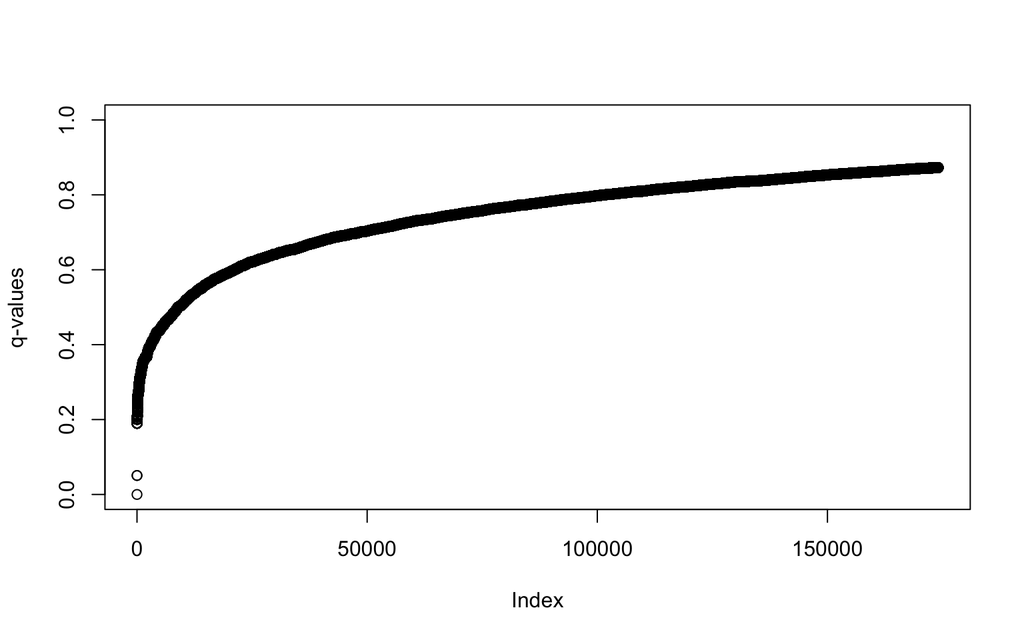

```r
plot(sort(NV2012$qvalues) , ylab="q-values", ylim=c(0,1) )
```

What is the lowest q-value we have?

```r
min(NV2012$qvalues)
```

```
## [1] 0
```

What interests us is the relationship between the q-value of interaction, and the R2 of the model. Let’s represent both, and check if we find out a pair of marker with a high R2 and a high interaction term? Every pair of markers will be blue, except the interactions between chromosome 7A and chromosome 7B. I will use dots only, except for representing the interaction between the QTL 7A and the QTL 7B described in the study.

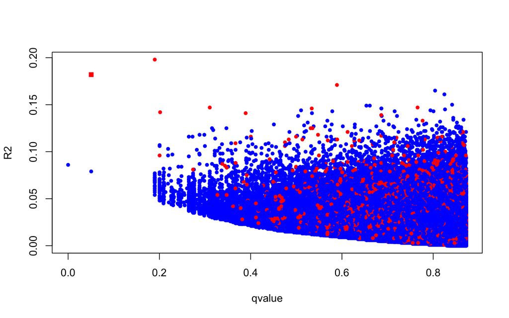

```r
my_colors=ifelse( (NV2012$chromo_ref=="7B" & NV2012$chromo_other=="7A") | (NV2012$chromo_ref=="7A" & NV2012$chromo_other=="7B") , "red" , "blue")
my_pch=ifelse( NV2012$chromo_ref=="7A" & NV2012$chromo_other=="7B" & NV2012$min_Kref>=115 & NV2012$max_Kref<=120 & NV2012$min_Kother>=45 & NV2012$max_Kother<=50 , 15, 20)
plot(NV2012$R2~NV2012$qvalues, col=my_colors, pch=my_pch, xlab="qvalue", ylab="R2" )
```

It is quite clear that the only relevant QTL is the one described in the study. A few other pairs of markers presents an interaction, but always with a small R2 and are thus probably due to hazard.

We can have a look to the 10 biggest R2:

```r
tmp1=head(NV2012[order(NV2012$R2, decreasing=T) , ], 10)
tmp2=head(NV2012[order(NV2012$qvalues) , ] , 10)
```

| pheno | chromo_ref | min_Kref | max_Kref | mark_ref | chromo_other | min_Kother | max_Kother | mark_Kother | R2 | pval_mark1 | pval_mark2 | pval_inter | qvalues |
| --- | --- | --- | --- | --- | --- | --- | --- | --- | --- | --- | --- | --- | --- |
| NV_blup_AR1_2012 | 7A | 115 | 120 | Cluster_17879\|Contig1\|likelySeq@409 | 7B | 55 | 60 | Cluster_932\|Contig1\|original@517 | 0.20 | 19.00 | 19.00 | 0.00 | 0.19 |
| NV_blup_AR1_2012 | 7A | 115 | 120 | Cluster_17879\|Contig1\|likelySeq@409 | 7B | 45 | 50 | Cluster_2114\|Contig3\|original@2227 | 0.18 | 19.00 | 19.00 | 0.00 | 0.05 |
| NV_blup_AR1_2012 | 7A | 125 | 130 | Cluster_8137\|Contig3\|original@2003 | 7B | 55 | 60 | Cluster_3623\|Contig2\|original@924 | 0.17 | 4.96 | 19.00 | 0.07 | 0.59 |
| NV_blup_AR1_2012 | 4B | 95 | 100 | Cluster_1185\|Contig2\|original@96 | 7B | 55 | 60 | Cluster_3623\|Contig2\|original@924 | 0.17 | 2.42 | 4.38 | 0.55 | 0.80 |
| NV_blup_AR1_2012 | 4A | 55 | 60 | Cluster_12204\|Contig1\|likelySeq@2065 | 7B | 55 | 60 | Cluster_3623\|Contig2\|original@924 | 0.16 | 2.48 | 4.17 | 0.66 | 0.82 |
| NV_blup_AR1_2012 | 4B | 100 | 105 | Cluster_11589\|Contig1\|original@203 | 7B | 55 | 60 | Cluster_932\|Contig1\|original@517 | 0.15 | 2.98 | 4.70 | 0.77 | 0.84 |
| NV_blup_AR1_2012 | 4A | 65 | 70 | Cluster_18343\|Contig1\|complementarySeq@1368 | 7B | 55 | 60 | Cluster_932\|Contig1\|original@517 | 0.15 | 1.37 | 4.07 | 0.16 | 0.66 |
| NV_blup_AR1_2012 | 7B | 55 | 60 | Cluster_3623\|Contig2\|original@924 | 7B | 190 | 195 | Cluster_2843\|Contig3\|original@1198 | 0.15 | 5.52 | 0.75 | 0.15 | 0.65 |
| NV_blup_AR1_2012 | 7A | 100 | 105 | Cluster_6826\|Contig3\|complementarySeq@624 | 7B | 55 | 60 | Cluster_3623\|Contig2\|original@924 | 0.15 | 3.17 | 19.00 | 0.40 | 0.77 |
| NV_blup_AR1_2012 | 7A | 115 | 120 | Cluster_17879\|Contig1\|likelySeq@409 | 7B | 85 | 90 | Cluster_8184\|Contig2\|original@531 | 0.15 | 19.00 | 19.00 | 0.00 | 0.31 |

As presented in this table, the highest R2 always involved QTL 7A or QTL 7B, or both.

Let’s look the 10 lowest qvalues:

| pheno | chromo_ref | min_Kref | max_Kref | mark_ref | chromo_other | min_Kother | max_Kother | mark_Kother | R2 | pval_mark1 | pval_mark2 | pval_inter | qvalues |
| --- | --- | --- | --- | --- | --- | --- | --- | --- | --- | --- | --- | --- | --- |
| NV_blup_AR1_2012 | 1A | 90 | 95 | Cluster_9208\|Contig1\|original@1858 | 6B | 150 | 155 | Cluster_14323\|Contig2\|original@958 | 0.09 | 3.71 | 4.74 | 0.00 | 0.00 |
| NV_blup_AR1_2012 | 4A | 160 | 165 | Cluster_5029\|Contig6\|likelySeq@165 | 4A | 145 | 150 | Cluster_11872\|Contig8\|original@205 | 0.08 | 2.73 | 5.00 | 0.00 | 0.05 |
| NV_blup_AR1_2012 | 7A | 115 | 120 | Cluster_17879\|Contig1\|likelySeq@409 | 7B | 45 | 50 | Cluster_2114\|Contig3\|original@2227 | 0.18 | 19.00 | 19.00 | 0.00 | 0.05 |
| NV_blup_AR1_2012 | 1A | 65 | 70 | Cluster_73\|Contig5\|likelySeq@1874 | 4A | 110 | 115 | Cluster_1986\|Contig1\|original@236 | 0.07 | 3.13 | 5.30 | 0.00 | 0.19 |
| NV_blup_AR1_2012 | 1A | 85 | 90 | Cluster_3611\|Contig2\|likelySeq@143 | 7A | 90 | 95 | Cluster_21715\|Contig3\|original@469 | 0.07 | 1.24 | 0.33 | 0.00 | 0.19 |
| NV_blup_AR1_2012 | 1A | 90 | 95 | Cluster_9208\|Contig1\|original@1858 | 6B | 145 | 150 | Cluster_14088\|Contig1\|complementarySeq@359 | 0.07 | 3.33 | 4.06 | 0.00 | 0.19 |
| NV_blup_AR1_2012 | 1A | 95 | 100 | Cluster_5844\|Contig3\|original@293 | 6B | 150 | 155 | Cluster_11335\|Contig3\|original@831 | 0.07 | 2.44 | 5.05 | 0.00 | 0.19 |
| NV_blup_AR1_2012 | 3A | 0 | 5 | Cluster_3261\|Contig1\|original@112 | 5B | 230 | 235 | Cluster_2698\|Contig2\|original@1306 | 0.07 | 5.10 | 2.34 | 0.00 | 0.19 |
| NV_blup_AR1_2012 | 3A | 0 | 5 | Cluster_3261\|Contig1\|original@112 | 5B | 240 | 245 | Cluster_10467\|Contig1\|original@1549 | 0.08 | 4.89 | 3.08 | 0.00 | 0.19 |
| NV_blup_AR1_2012 | 3A | 155 | 160 | Cluster_1292\|Contig2\|original@87 | 5B | 180 | 185 | Cluster_11865\|Contig3\|original@318 | 0.06 | 3.05 | 2.57 | 0.00 | 0.19 |

## Elisa 2012

Calculate qvalue from pvalues

```r
qv = qvalue(p=Elisa2012$pval_inter, fdr.level=0.05, robust=TRUE)
Elisa2012$qvalues=qv$qvalues
```

transforme pvalues of markers in LOD:

```r
Elisa2012$pval_mark1=-log10(Elisa2012$pval_mark1+0.0000000000000000001)
Elisa2012$pval_mark2=-log10(Elisa2012$pval_mark2+0.0000000000000000001)
```

How many significant interactions do we have?

```r
my_signif=Elisa2012[which(Elisa2012$qvalues<0.05) , ]
nrow(my_signif)
```

```
## [1] 6
```

Let’s show the details of these significant interactions:

| pheno | chromo_ref | min_Kref | max_Kref | mark_ref | chromo_other | min_Kother | max_Kother | mark_Kother | R2 | pval_mark1 | pval_mark2 | pval_inter | qvalues |
| --- | --- | --- | --- | --- | --- | --- | --- | --- | --- | --- | --- | --- | --- |
| ELISA_blup_AR1_2012 | 4A | 20 | 25 | Cluster_622\|Contig5\|original@894 | 5B | 35 | 40 | Cluster_3003\|Contig2\|original@468 | 0.08 | 4.82 | 0.92 | 0.00 | 0.00 |
| ELISA_blup_AR1_2012 | 7A | 100 | 105 | Cluster_811\|Contig2\|original@731 | 7B | 55 | 60 | Cluster_932\|Contig1\|original@517 | 0.26 | 19.00 | 19.00 | 0.00 | 0.03 |
| ELISA_blup_AR1_2012 | 7A | 100 | 105 | Cluster_811\|Contig2\|original@731 | 7B | 80 | 85 | Cluster_3627\|Contig1\|complementarySeq@440 | 0.18 | 19.00 | 19.00 | 0.00 | 0.00 |
| ELISA_blup_AR1_2012 | 7A | 100 | 105 | Cluster_811\|Contig2\|original@731 | 7B | 85 | 90 | Cluster_3743\|Contig5\|original@2638 | 0.20 | 19.00 | 19.00 | 0.00 | 0.03 |
| ELISA_blup_AR1_2012 | 7A | 115 | 120 | Cluster_17879\|Contig1\|likelySeq@409 | 7B | 80 | 85 | Cluster_3627\|Contig1\|complementarySeq@440 | 0.28 | 19.00 | 19.00 | 0.00 | 0.00 |
| ELISA_blup_AR1_2012 | 7A | 115 | 120 | Cluster_17879\|Contig1\|likelySeq@409 | 7B | 90 | 95 | Cluster_7636\|Contig1\|original@1632 | 0.28 | 19.00 | 19.00 | 0.00 | 0.03 |

The same representation as above, looking for relationship between R2 and qvalue, highlighting the QTL and 7A x 7B interactions:

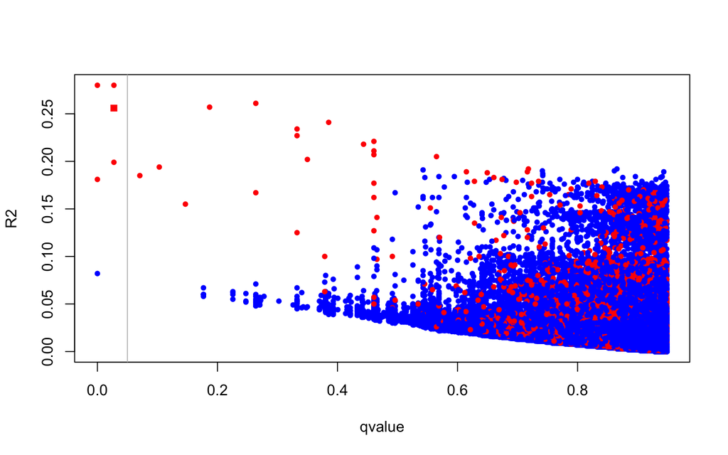

```r
my_colors=ifelse( (Elisa2012$chromo_ref=="7B" & Elisa2012$chromo_other=="7A") | (Elisa2012$chromo_ref=="7A" & Elisa2012$chromo_other=="7B") , "red" , "blue")
my_pch=ifelse( Elisa2012$chromo_ref=="7A" & Elisa2012$chromo_other=="7B" & Elisa2012$min_Kref>=100 & Elisa2012$max_Kref<=105 & Elisa2012$min_Kother>=55 & Elisa2012$max_Kother<=60 , 15, 20)
plot(Elisa2012$R2~Elisa2012$qvalues, col=my_colors, pch=my_pch, xlab="qvalue", ylab="R2" )
abline(v=0.05, col="grey")
```

//: =========================================================================================================================

## NV 2015

Calculate qvalue from pvalues

```r
qv = qvalue(p=NV2015$pval_inter, fdr.level=0.05, robust=TRUE)
NV2015$qvalues=qv$qvalues
```

transforme pvalues of markers in LOD:

```r
NV2015$pval_mark1=-log10(NV2015$pval_mark1+0.0000000000000000001)
NV2015$pval_mark2=-log10(NV2015$pval_mark2+0.0000000000000000001)
```

How many significant interactions do we have?

```r
my_signif=NV2015[which(NV2015$qvalues<0.05) , ]
nrow(my_signif)
```

```
## [1] 4
```

Let’s show the details of these significant interactions:

| pheno | chromo_ref | min_Kref | max_Kref | mark_ref | chromo_other | min_Kother | max_Kother | mark_Kother | R2 | pval_mark1 | pval_mark2 | pval_inter | qvalues |
| --- | --- | --- | --- | --- | --- | --- | --- | --- | --- | --- | --- | --- | --- |
| NV_blup_AR1_2015 | 2A | 170 | 175 | Cluster_6201\|Contig2\|original@351 | 4B | 155 | 160 | Cluster_1288\|Contig2\|original@142 | 0.08 | 1.04 | 4.07 | 0.00 | 0.00 |
| NV_blup_AR1_2015 | 4A | 145 | 150 | Cluster_11872\|Contig8\|original@205 | 4A | 160 | 165 | Cluster_5029\|Contig6\|likelySeq@165 | 0.08 | 5.10 | 2.89 | 0.00 | 0.04 |
| NV_blup_AR1_2015 | 4A | 160 | 165 | Cluster_8384\|Contig2\|likelySeq@315 | 4A | 145 | 150 | Cluster_11872\|Contig8\|original@205 | 0.09 | 2.89 | 5.52 | 0.00 | 0.00 |
| NV_blup_AR1_2015 | 4A | 160 | 165 | Cluster_8384\|Contig2\|likelySeq@315 | 4A | 150 | 155 | Cluster_9132\|Contig1\|likelySeq@42 | 0.08 | 3.02 | 5.10 | 0.00 | 0.04 |

Let’s represent the qvalues we have:

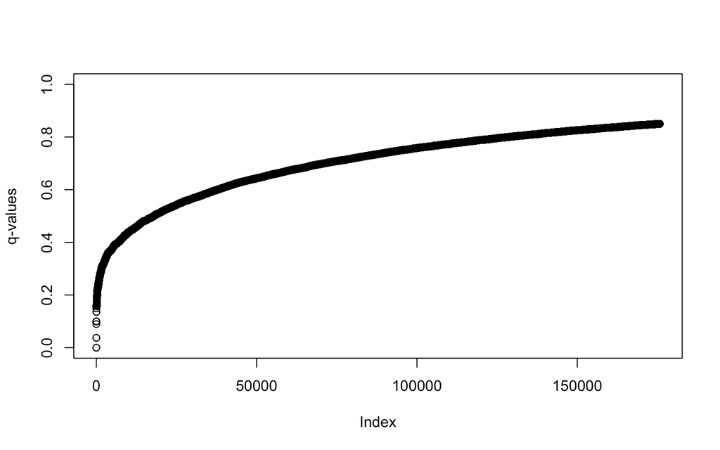

```r
plot(sort(NV2015$qvalues) , ylab="q-values", ylim=c(0,1) )
```

Representation of R2 and qvalues

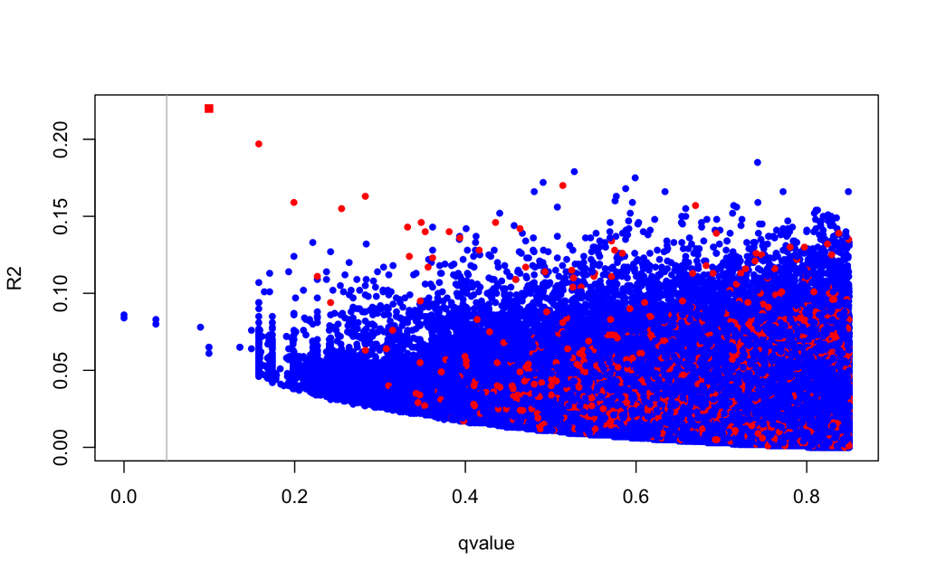

```r
my_colors=ifelse( (NV2015$chromo_ref=="7B" & NV2015$chromo_other=="7A") | (NV2015$chromo_ref=="7A" & NV2015$chromo_other=="7B") , "red" , "blue")
my_pch=ifelse( NV2015$chromo_ref=="7A" & NV2015$chromo_other=="7B" & NV2015$min_Kref>=115 & NV2015$max_Kref<=120 & NV2015$min_Kother>=55 & NV2015$max_Kother<=60 , 15, 20)
plot(NV2015$R2~NV2015$qvalues, col=my_colors, pch=my_pch, xlab="qvalue", ylab="R2" )
abline(v=0.05, col="grey")
```

It is quite clear that the only relevant QTL is the one described in the study. A few other pairs of markers presents an interaction, but always with a small R2 and are thus probably due to hazard.

We can have a look to the 10 biggest R2:

```r
tmp1=head(NV2015[order(NV2015$R2, decreasing=T) , ], 10)
tmp2=head(NV2015[order(NV2015$qvalues) , ] , 10)
```

| pheno | chromo_ref | min_Kref | max_Kref | mark_ref | chromo_other | min_Kother | max_Kother | mark_Kother | R2 | pval_mark1 | pval_mark2 | pval_inter | qvalues |
| --- | --- | --- | --- | --- | --- | --- | --- | --- | --- | --- | --- | --- | --- |
| NV_blup_AR1_2015 | 7A | 115 | 120 | Cluster_932\|Contig2\|original@602 | 7B | 55 | 60 | Cluster_932\|Contig1\|original@517 | 0.22 | 19.00 | 19.00 | 0.00 | 0.10 |
| NV_blup_AR1_2015 | 7A | 115 | 120 | Cluster_932\|Contig2\|original@602 | 7B | 50 | 55 | Cluster_8668\|Contig2\|original@192 | 0.20 | 19.00 | 19.00 | 0.00 | 0.16 |
| NV_blup_AR1_2015 | 2A | 215 | 220 | Cluster_14091\|Contig1\|original@109 | 4B | 100 | 105 | Cluster_6287\|Contig3\|original@107 | 0.18 | 19.00 | 6.00 | 0.45 | 0.74 |
| NV_blup_AR1_2015 | 2A | 215 | 220 | Cluster_14091\|Contig1\|original@109 | 7B | 55 | 60 | Cluster_932\|Contig1\|original@517 | 0.18 | 1.85 | 2.60 | 0.08 | 0.53 |
| NV_blup_AR1_2015 | 7B | 190 | 195 | Cluster_1989\|Contig7\|original@189 | 7B | 55 | 60 | Cluster_3623\|Contig2\|original@924 | 0.17 | 1.33 | 19.00 | 0.15 | 0.60 |
| NV_blup_AR1_2015 | 2A | 185 | 190 | Cluster_6910\|Contig1\|original@443 | 7B | 55 | 60 | Cluster_3623\|Contig2\|original@924 | 0.17 | 1.08 | 3.81 | 0.05 | 0.49 |
| NV_blup_AR1_2015 | 7A | 125 | 130 | Cluster_9668\|Contig1\|complementarySeq@303 | 7B | 55 | 60 | Cluster_932\|Contig3\|original@346 | 0.17 | 4.89 | 19.00 | 0.07 | 0.51 |
| NV_blup_AR1_2015 | 2A | 215 | 220 | Cluster_14091\|Contig1\|original@109 | 7A | 115 | 120 | Cluster_2439\|Contig7\|original@810 | 0.17 | 19.00 | 5.70 | 0.14 | 0.59 |
| NV_blup_AR1_2015 | 2A | 205 | 210 | Cluster_14710\|Contig1\|original@326 | 7B | 55 | 60 | Cluster_3623\|Contig2\|original@924 | 0.17 | 1.29 | 3.47 | 0.20 | 0.63 |
| NV_blup_AR1_2015 | 2A | 215 | 220 | Cluster_14091\|Contig1\|original@109 | 7B | 50 | 55 | Cluster_8668\|Contig2\|original@192 | 0.17 | 1.77 | 1.92 | 0.05 | 0.48 |

Let’s look the 10 lowest qvalues:

| pheno | chromo_ref | min_Kref | max_Kref | mark_ref | chromo_other | min_Kother | max_Kother | mark_Kother | R2 | pval_mark1 | pval_mark2 | pval_inter | qvalues |
| --- | --- | --- | --- | --- | --- | --- | --- | --- | --- | --- | --- | --- | --- |
| NV_blup_AR1_2015 | 2A | 170 | 175 | Cluster_6201\|Contig2\|original@351 | 4B | 155 | 160 | Cluster_1288\|Contig2\|original@142 | 0.08 | 1.04 | 4.07 | 0.00 | 0.00 |
| NV_blup_AR1_2015 | 4A | 160 | 165 | Cluster_8384\|Contig2\|likelySeq@315 | 4A | 145 | 150 | Cluster_11872\|Contig8\|original@205 | 0.09 | 2.89 | 5.52 | 0.00 | 0.00 |
| NV_blup_AR1_2015 | 4A | 145 | 150 | Cluster_11872\|Contig8\|original@205 | 4A | 160 | 165 | Cluster_5029\|Contig6\|likelySeq@165 | 0.08 | 5.10 | 2.89 | 0.00 | 0.04 |
| NV_blup_AR1_2015 | 4A | 160 | 165 | Cluster_8384\|Contig2\|likelySeq@315 | 4A | 150 | 155 | Cluster_9132\|Contig1\|likelySeq@42 | 0.08 | 3.02 | 5.10 | 0.00 | 0.04 |
| NV_blup_AR1_2015 | 3A | 0 | 5 | Cluster_6008\|Contig1\|original@625 | 5B | 245 | 250 | Cluster_8784\|Contig1\|original@431 | 0.08 | 4.44 | 3.68 | 0.00 | 0.09 |
| NV_blup_AR1_2015 | 2B | 105 | 110 | Cluster_1202\|Contig5\|original@10551 | 5B | 210 | 215 | Cluster_1322\|Contig2\|original@1062 | 0.07 | 2.25 | 3.77 | 0.00 | 0.10 |
| NV_blup_AR1_2015 | 2A | 170 | 175 | Cluster_6201\|Contig2\|original@351 | 4B | 145 | 150 | Cluster_5054\|Contig2\|original@179 | 0.07 | 0.64 | 3.19 | 0.00 | 0.10 |
| NV_blup_AR1_2015 | 2B | 105 | 110 | Cluster_1202\|Contig5\|original@10551 | 5B | 200 | 205 | Cluster_4194\|Contig2\|complementarySeq@406 | 0.06 | 2.61 | 2.57 | 0.00 | 0.10 |
| NV_blup_AR1_2015 | 7A | 115 | 120 | Cluster_932\|Contig2\|original@602 | 7B | 55 | 60 | Cluster_932\|Contig1\|original@517 | 0.22 | 19.00 | 19.00 | 0.00 | 0.10 |
| NV_blup_AR1_2015 | 1B | 225 | 230 | Cluster_9819\|Contig1\|original@723 | 6A | 95 | 100 | Cluster_1195\|Contig1\|complementarySeq@2217 | 0.07 | 4.09 | 1.80 | 0.00 | 0.14 |

## Elisa 2015

Calculate qvalue from pvalues

```r
qv = qvalue(p=Elisa2015$pval_inter, fdr.level=0.05, robust=TRUE)
Elisa2015$qvalues=qv$qvalues
```

transforme pvalues of markers in LOD:

```r
Elisa2015$pval_mark1=-log10(Elisa2015$pval_mark1+0.0000000000000000001)
Elisa2015$pval_mark2=-log10(Elisa2015$pval_mark2+0.0000000000000000001)
```

How many significant interactions do we have?

```r
my_signif=Elisa2015[which(Elisa2015$qvalues<0.05) , ]
nrow(my_signif)
```

```
## [1] 2
```

Let’s show the details of these significant interactions:

| pheno | chromo_ref | min_Kref | max_Kref | mark_ref | chromo_other | min_Kother | max_Kother | mark_Kother | R2 | pval_mark1 | pval_mark2 | pval_inter | qvalues |
| --- | --- | --- | --- | --- | --- | --- | --- | --- | --- | --- | --- | --- | --- |
| ELISA_blup_AR1_2015 | 3A | 10 | 15 | Cluster_10171\|Contig1\|original@3288 | 5A | 230 | 235 | Cluster_11126\|Contig1\|original@548 | 0.08 | 1.95 | 2.68 | 0.00 | 0.00 |
| ELISA_blup_AR1_2015 | 7A | 115 | 120 | Cluster_10461\|Contig1\|likelySeq@159 | 7B | 80 | 85 | Cluster_6554\|Contig2\|original@852 | 0.28 | 19.00 | 19.00 | 0.00 | 0.00 |

The same representation as above, looking for relationship between R2 and qvalue, highlighting the QTL and 7A x 7B interactions:

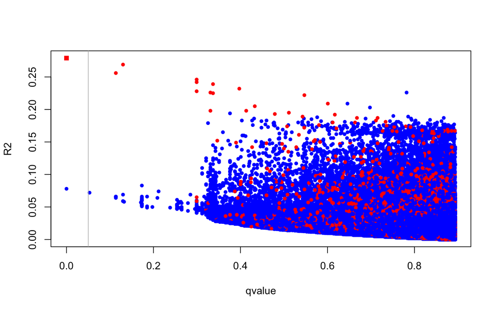

```r
my_colors=ifelse( (Elisa2015$chromo_ref=="7B" & Elisa2015$chromo_other=="7A") | (Elisa2015$chromo_ref=="7A" & Elisa2015$chromo_other=="7B") , "red" , "blue")
my_pch=ifelse( Elisa2015$chromo_ref=="7A" & Elisa2015$chromo_other=="7B" & Elisa2015$min_Kref>=115 & Elisa2015$max_Kref<=120 & Elisa2015$min_Kother>=80 & Elisa2015$max_Kother<=85 , 15, 20)
plot(Elisa2015$R2~Elisa2015$qvalues, col=my_colors, pch=my_pch, xlab="qvalue", ylab="R2" )
abline(v=0.05, col="grey")
```

//: =========================================================================================================================

## QPCR 2015

Calculate qvalue from pvalues

```r
qv = qvalue(p=qPCR2015$pval_inter, fdr.level=0.05, robust=TRUE)
qPCR2015$qvalues=qv$qvalues
```

transforme pvalues of markers in LOD:

```r
qPCR2015$pval_mark1=-log10(qPCR2015$pval_mark1+0.0000000000000000001)
qPCR2015$pval_mark2=-log10(qPCR2015$pval_mark2+0.0000000000000000001)
```

How many significant interactions do we have?

```r
a=qPCR2015[which(qPCR2015$qvalues<0.05) , ]
nrow(a)
```

```
## [1] 4
```

|  | pheno | chromo_ref | min_Kref | max_Kref | mark_ref | chromo_other | min_Kother | max_Kother | mark_Kother | R2 | pval_mark1 | pval_mark2 | pval_inter | qvalues |
| --- | --- | --- | --- | --- | --- | --- | --- | --- | --- | --- | --- | --- | --- | --- |
| 225071 | QPCR_blup_AR1_2015 | 7A | 115 | 120 | Cluster_16523\|Contig1\|complementarySeq@373 | 7B | 50 | 55 | Cluster_8668\|Contig2\|original@192 | 0.25 | 19.00 | 19.00 | 0.00 | 0.00 |
| 225077 | QPCR_blup_AR1_2015 | 7A | 115 | 120 | Cluster_16523\|Contig1\|complementarySeq@373 | 7B | 80 | 85 | Cluster_9012\|Contig1\|original@267 | 0.15 | 19.00 | 19.00 | 0.00 | 0.04 |
| 225255 | QPCR_blup_AR1_2015 | 7A | 125 | 130 | Cluster_1722\|Contig1\|original@583 | 7B | 50 | 55 | Cluster_8668\|Contig2\|original@192 | 0.19 | 19.00 | 19.00 | 0.00 | 0.04 |
| 225261 | QPCR_blup_AR1_2015 | 7A | 125 | 130 | Cluster_1722\|Contig1\|original@583 | 7B | 80 | 85 | Cluster_8884\|Contig1\|complementarySeq@1336 | 0.11 | 19.00 | 5.05 | 0.00 | 0.04 |

Let’s represent the qvalues we have:

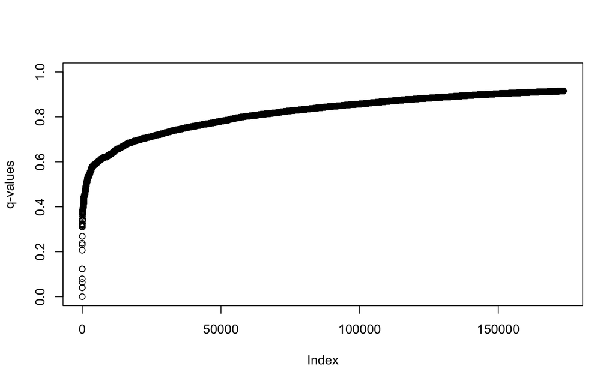

```r
plot(sort(qPCR2015$qvalues) , ylab="q-values", ylim=c(0,1) )
```

What is the lowest q-value we have?

```r
min(qPCR2015$qvalues)
```

```
## [1] 0
```

What interests us is the relationship between the q-value of interaction, and the R2 of the model. Let’s represent both, and check if we find out a pair of marker with a high R2 and a high interaction term? Every pair of markers will be blue, except the interactions between chromosome 7A and chromosome 7B. I will use dots only, except for representing the interaction between the QTL 7A and the QTL 7B described in the study.

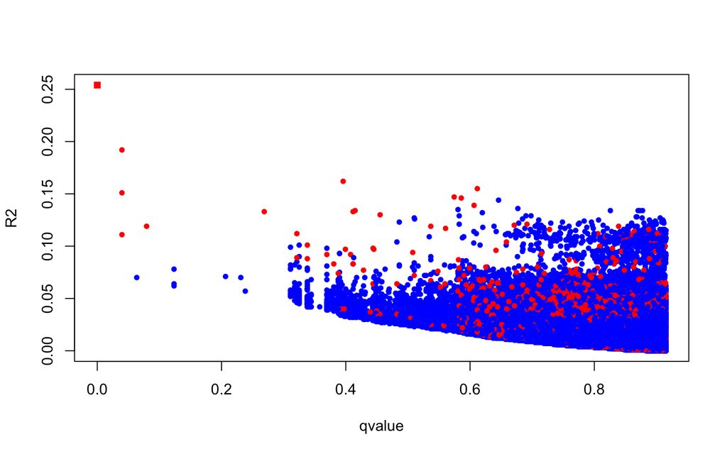

```r
my_colors=ifelse( (qPCR2015$chromo_ref=="7B" & qPCR2015$chromo_other=="7A") | (qPCR2015$chromo_ref=="7A" & qPCR2015$chromo_other=="7B") , "red" , "blue")
my_pch=ifelse( qPCR2015$chromo_ref=="7A" & qPCR2015$chromo_other=="7B" & qPCR2015$min_Kref>=115 & qPCR2015$max_Kref<=120 & qPCR2015$min_Kother>=50 & qPCR2015$max_Kother<=55 , 15, 20)
plot(qPCR2015$R2~qPCR2015$qvalues, col=my_colors, pch=my_pch, xlab="qvalue", ylab="R2" )
```

It is quite clear that the only relevant QTL is the one described in the study. A few other pairs of markers presents an interaction, but always with a small R2 and are thus probably due to hazard.

We can have a look to the 10 biggest R2:

```r
tmp1=head(qPCR2015[order(qPCR2015$R2, decreasing=T) , ], 10)
tmp2=head(qPCR2015[order(qPCR2015$qvalues) , ] , 10)
```

| pheno | chromo_ref | min_Kref | max_Kref | mark_ref | chromo_other | min_Kother | max_Kother | mark_Kother | R2 | pval_mark1 | pval_mark2 | pval_inter | qvalues |
| --- | --- | --- | --- | --- | --- | --- | --- | --- | --- | --- | --- | --- | --- |
| QPCR_blup_AR1_2015 | 7A | 115 | 120 | Cluster_16523\|Contig1\|complementarySeq@373 | 7B | 50 | 55 | Cluster_8668\|Contig2\|original@192 | 0.25 | 19.00 | 19.00 | 0.00 | 0.00 |
| QPCR_blup_AR1_2015 | 7A | 125 | 130 | Cluster_1722\|Contig1\|original@583 | 7B | 50 | 55 | Cluster_8668\|Contig2\|original@192 | 0.19 | 19.00 | 19.00 | 0.00 | 0.04 |
| QPCR_blup_AR1_2015 | 7A | 105 | 110 | Cluster_9397\|Contig1\|likelySeq@1055 | 7B | 50 | 55 | Cluster_8668\|Contig2\|original@192 | 0.16 | 5.52 | 19.00 | 0.00 | 0.40 |
| QPCR_blup_AR1_2015 | 7A | 130 | 135 | Cluster_10762\|Contig2\|original@86 | 7B | 50 | 55 | Cluster_8668\|Contig2\|original@192 | 0.15 | 4.85 | 19.00 | 0.03 | 0.61 |
| QPCR_blup_AR1_2015 | 7A | 115 | 120 | Cluster_16523\|Contig1\|complementarySeq@373 | 7B | 80 | 85 | Cluster_9012\|Contig1\|original@267 | 0.15 | 19.00 | 19.00 | 0.00 | 0.04 |
| QPCR_blup_AR1_2015 | 7A | 95 | 100 | Cluster_10130\|Contig1\|complementarySeq@473 | 7B | 55 | 60 | Cluster_3623\|Contig2\|original@924 | 0.15 | 4.04 | 19.00 | 0.01 | 0.57 |
| QPCR_blup_AR1_2015 | 7A | 100 | 105 | Cluster_10107\|Contig2\|likelySeq@262 | 7B | 55 | 60 | Cluster_3623\|Contig2\|original@924 | 0.15 | 4.36 | 19.00 | 0.02 | 0.59 |
| QPCR_blup_AR1_2015 | 5A | 0 | 5 | Cluster_3397\|Contig1\|complementarySeq@200 | 7B | 50 | 55 | Cluster_8668\|Contig2\|original@192 | 0.14 | 1.05 | 2.80 | 0.05 | 0.65 |
| QPCR_blup_AR1_2015 | 7A | 135 | 140 | Cluster_730\|Contig2\|complementarySeq@3177 | 7B | 55 | 60 | Cluster_932\|Contig3\|original@346 | 0.14 | 4.72 | 19.00 | 0.02 | 0.61 |
| QPCR_blup_AR1_2015 | 2B | 10 | 15 | Cluster_600\|Contig4\|original@1198 | 7B | 55 | 60 | Cluster_3623\|Contig2\|original@924 | 0.14 | 1.99 | 2.91 | 0.07 | 0.68 |

As presented in this table, the highest R2 always involved QTL 7A or QTL 7B, or both.

Let’s look the 10 lowest qvalues:

| pheno | chromo_ref | min_Kref | max_Kref | mark_ref | chromo_other | min_Kother | max_Kother | mark_Kother | R2 | pval_mark1 | pval_mark2 | pval_inter | qvalues |
| --- | --- | --- | --- | --- | --- | --- | --- | --- | --- | --- | --- | --- | --- |
| QPCR_blup_AR1_2015 | 7A | 115 | 120 | Cluster_16523\|Contig1\|complementarySeq@373 | 7B | 50 | 55 | Cluster_8668\|Contig2\|original@192 | 0.25 | 19.00 | 19.00 | 0.00 | 0.00 |
| QPCR_blup_AR1_2015 | 7A | 115 | 120 | Cluster_16523\|Contig1\|complementarySeq@373 | 7B | 80 | 85 | Cluster_9012\|Contig1\|original@267 | 0.15 | 19.00 | 19.00 | 0.00 | 0.04 |
| QPCR_blup_AR1_2015 | 7A | 125 | 130 | Cluster_1722\|Contig1\|original@583 | 7B | 50 | 55 | Cluster_8668\|Contig2\|original@192 | 0.19 | 19.00 | 19.00 | 0.00 | 0.04 |
| QPCR_blup_AR1_2015 | 7A | 125 | 130 | Cluster_1722\|Contig1\|original@583 | 7B | 80 | 85 | Cluster_8884\|Contig1\|complementarySeq@1336 | 0.11 | 19.00 | 5.05 | 0.00 | 0.04 |
| QPCR_blup_AR1_2015 | 3A | 10 | 15 | Cluster_10171\|Contig1\|original@3288 | 5A | 250 | 255 | Cluster_10187\|Contig1\|complementarySeq@502 | 0.07 | 1.99 | 1.54 | 0.00 | 0.06 |
| QPCR_blup_AR1_2015 | 7A | 125 | 130 | Cluster_1722\|Contig1\|original@583 | 7B | 90 | 95 | Cluster_6745\|Contig2\|original@111 | 0.12 | 19.00 | 19.00 | 0.00 | 0.08 |
| QPCR_blup_AR1_2015 | 1A | 110 | 115 | Cluster_10416\|Contig1\|original@242 | 7A | 225 | 230 | Cluster_5352\|Contig3\|original@291 | 0.06 | 1.97 | 2.31 | 0.00 | 0.12 |
| QPCR_blup_AR1_2015 | 1B | 170 | 175 | Cluster_9241\|Contig2\|complementarySeq@284 | 7A | 55 | 60 | Cluster_6112\|Contig1\|original@1269 | 0.06 | 1.70 | 1.98 | 0.00 | 0.12 |
| QPCR_blup_AR1_2015 | 3B | 160 | 165 | Cluster_798\|Contig5\|original@1881 | 4B | 115 | 120 | Cluster_7998\|Contig2\|original@291 | 0.08 | 4.04 | 4.80 | 0.00 | 0.12 |
| QPCR_blup_AR1_2015 | 4B | 110 | 115 | Cluster_7008\|Contig2\|original@125 | 6A | 110 | 115 | Cluster_11896\|Contig2\|original@393 | 0.07 | 0.45 | 4.03 | 0.00 | 0.21 |

Yan Holtz

December 2016